# sparrow_project

Published

April 24, 2026

Research question:

How do insect abundance and ambient noise levels affect the number of fledglings per nest in house sparrows?

## 1 Prepare Session

For this exercise all the code will be available either directly or folded.

```r
#importing libraries
  library(pastecs)
  library(ggplot2)
  library(ggpubr); theme_set(theme_bw())
  library(GGally)
  library(performance)
  library(MuMIn)
  library(ggeffects)
  library(tidyverse)

  library(knitr)

#import data

library(here)

clean <- read_delim(
  here("data", "processed", "clean.csv"),
  delim = ";",
  escape_double = FALSE,
  trim_ws = TRUE
)
```

## 2 Explore Data

### 2.1 Numerically

```r
sum_stats<-
   stat.desc(clean[, c("num_fledglings", "insect_abundance", "noise")], norm= T)

kable(sum_stats, digits=1)
```

Table 1: Descriptive statistics for the variables of interest.

|  | num_fledglings | insect_abundance | noise |
| --- | --- | --- | --- |
| nbr.val | 40.0 | 40.0 | 40.0 |
| nbr.null | 0.0 | 0.0 | 0.0 |
| nbr.na | 0.0 | 0.0 | 0.0 |
| min | 3.0 | 6.0 | 45.0 |
| max | 7.0 | 16.0 | 88.0 |
| range | 4.0 | 10.0 | 43.0 |
| sum | 189.0 | 422.0 | 2338.0 |
| median | 5.0 | 10.5 | 58.5 |
| mean | 4.7 | 10.6 | 58.5 |
| SE.mean | 0.2 | 0.5 | 1.3 |
| CI.mean.0.95 | 0.4 | 1.0 | 2.5 |
| var | 1.8 | 9.2 | 63.0 |
| std.dev | 1.3 | 3.0 | 7.9 |
| coef.var | 0.3 | 0.3 | 0.1 |
| skewness | 0.2 | 0.1 | 1.0 |
| skew.2SE | 0.3 | 0.2 | 1.3 |
| kurtosis | -1.2 | -1.2 | 2.7 |
| kurt.2SE | -0.8 | -0.8 | 1.8 |
| normtest.W | 0.9 | 0.9 | 0.9 |
| normtest.p | 0.0 | 0.1 | 0.0 |

### 2.2 Graphically

```r
# Scatterplot matrix
  ggpairs(clean[, c("num_fledglings", "insect_abundance", "noise")])
```

[output not shown]

Looking at Figure 1 following assumptions can be made:

a) Insect abundance (left panel)

There is a clear positive relationship between insect abundance and number of fledglings. This leads to the interpretation that higher food availability is associated with increased reproductive success.

The confidence band broadens at higher values meaning more uncertainty probably because of fewer observations.

b) Environmental noise (right panel)

There is a clear negative relationship between environmental noise and number of fledglings. This fact leads to the interpretation that higher environmental noise is associated with reduced reproductive success.

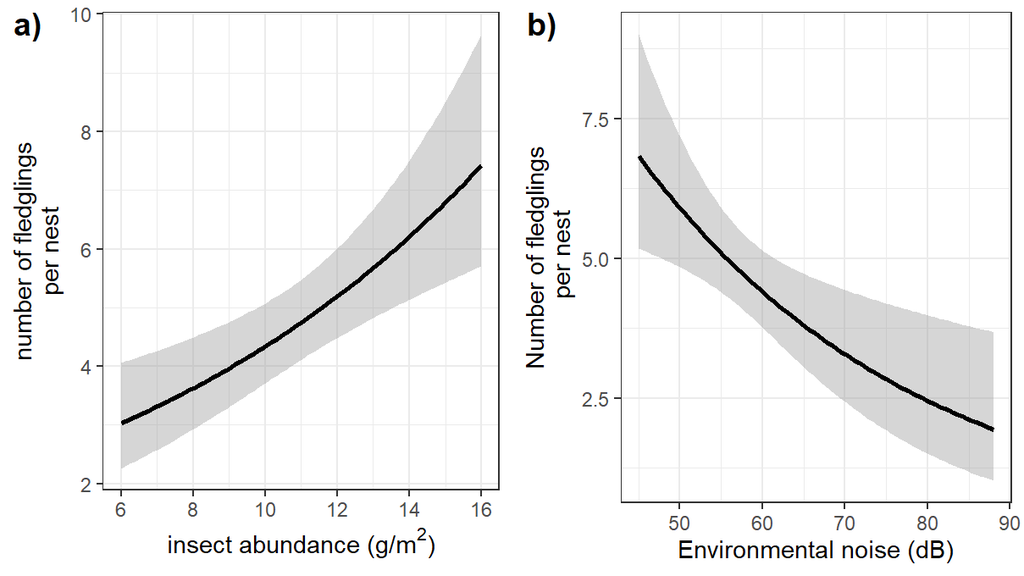

Figure 1: The number of fledglings per nest plotted against the two independent variables (a) insect abundance (g/$m^2$), and b) environmental noise).

```r
# Draw a graph that captures the research question
  ggarrange(
    ggplot(clean, aes(insect_abundance, num_fledglings)) +
      geom_smooth(method= glm, method.args= list(family= "poisson"),
                  col= "black") +
      labs(x= expression("insect abundance (g/" * m^2 * ")"),
           y= "number of fledglings\n per nest "),
    ggplot(clean, aes(noise, num_fledglings)) +
      geom_smooth(method= glm, method.args= list(family= "poisson"),
                  col= "black") +
      labs(x= "Environmental noise (dB)",
           y= "Number of fledglings\n per nest"),
    nrow= 1, ncol= 2, common.legend= T, labels= c("a)", "b)"))
```

The non-linear nature of both relationships (curvature) supports the use of a generalized linear model rather than simple linear regression.

## 3 Fit models

### 3.1 Formulate and compare

As seen in Table 2 further analysis with `glm.01` seems like the safest choice. This choice is based on the lowest AIC score and the highest Weight score.

```r
# Fit binomial glms
  glm.00<- glm(num_fledglings ~ 1, family= "poisson", clean)
  glm.01<- glm(num_fledglings ~ insect_abundance + noise,
               family= "poisson", clean)
  glm.02<- glm(num_fledglings ~ insect_abundance * noise,
               family= "poisson", clean)

# Compare models
  kable(compare_performance(glm.00, glm.01, glm.02), digits= 3)
```

Table 2: Model comparison.

| Name | Model | AIC | AIC_wt | AICc | AICc_wt | BIC | BIC_wt | R2_Nagelkerke | RMSE | Sigma | Score_log | Score_spherical |
| --- | --- | --- | --- | --- | --- | --- | --- | --- | --- | --- | --- | --- |
| glm.00 | glm | 152.365 | 0.005 | 152.470 | 0.008 | 154.054 | 0.033 | 0.000 | 1.323 | 1 | -1.880 | 0.155 |
| glm.01 | glm | 142.557 | 0.726 | 143.224 | 0.768 | 147.624 | 0.834 | 0.943 | 0.326 | 1 | -1.707 | 0.157 |
| glm.02 | glm | 144.547 | 0.269 | 145.690 | 0.224 | 151.303 | 0.133 | 0.944 | 0.324 | 1 | -1.707 | 0.157 |

### 3.2 Validate preferred model

```r
# First thing: check overdispersion
  check_overdispersion(glm.01)
```

```
# Overdispersion test

       dispersion ratio = 0.028
  Pearson's Chi-Squared = 1.020
                p-value =     1
```

No overdispersion in the data detected.

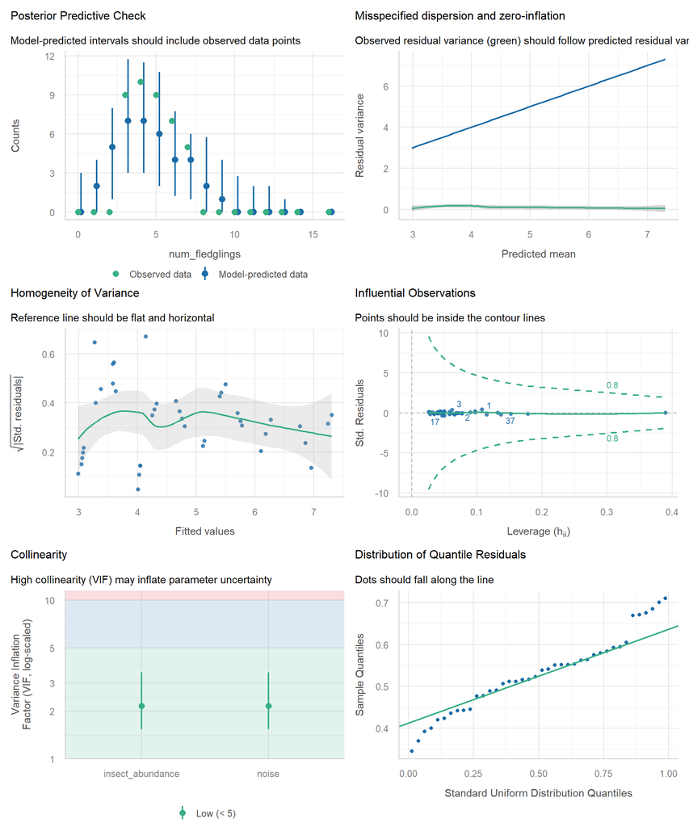

Figure 2: Model diagnostics

```r
# Validate model
  check_model(glm.01)
```

```r
library(MASS)

glm.nb.01 <- glm.nb(num_fledglings ~ insect_abundance + noise,
                    data = clean)

compare_performance(glm.01, glm.nb.01)
```

```
# Comparison of Model Performance Indices

Name      |  Model | AIC (weights) | AICc (weights) | BIC (weights)
-------------------------------------------------------------------
glm.01    |    glm | 142.6 (0.731) |  143.2 (0.775) | 147.6 (0.863)
glm.nb.01 | negbin | 144.6 (0.269) |  145.7 (0.225) | 151.3 (0.137)

Name      | Nagelkerke's R2 |  RMSE | Sigma | Score_log | Score_spherical
-------------------------------------------------------------------------
glm.01    |           0.943 | 0.326 |     1 |    -1.707 |           0.157
glm.nb.01 |           0.943 | 0.326 |     1 |    -2.608 |           0.153
```

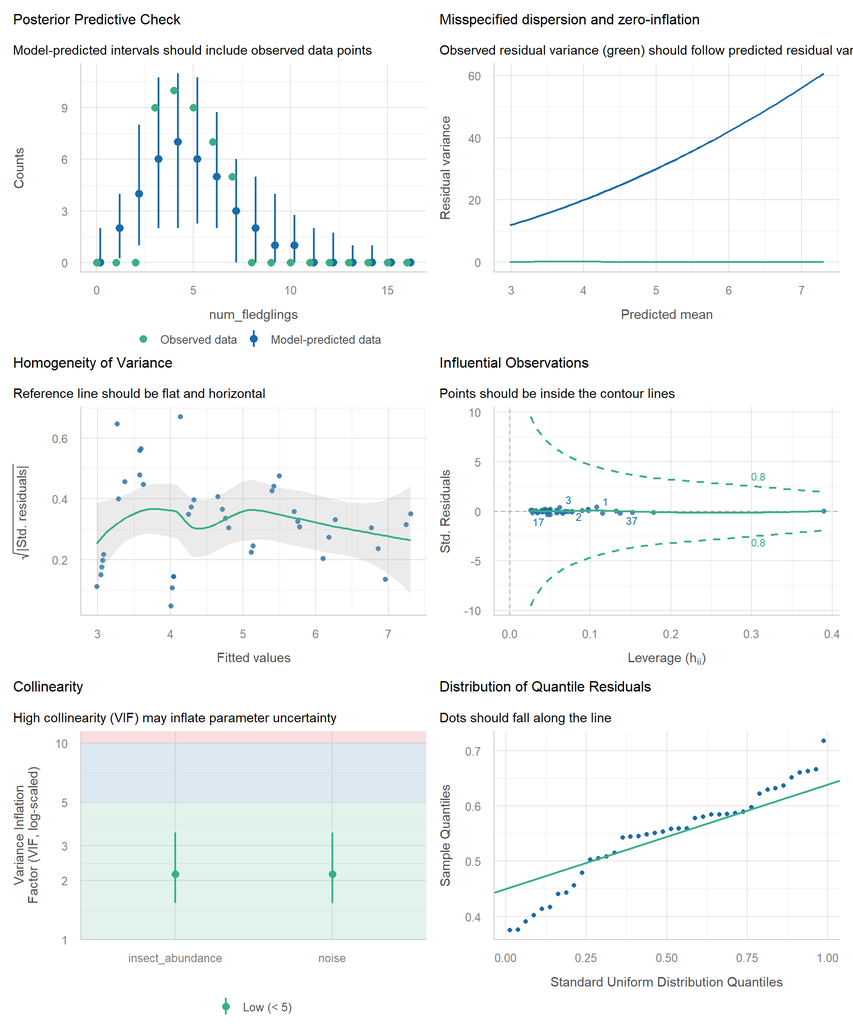

Figure 3: Model diagnostics

```r
check_model(glm.nb.01)
```

A negative binomial model did not improve model fit. Given that the Poisson model remained the best-performing model based on AIC and the alternative model did not provide improvement, the Poisson GLM was kept for further analysis.

## 4 Interpret preferred model

```r
# Objects to construct table ------------------------------------------------

## Coefficients, SE, z and p -----
  coef.table<- round(summary(glm.01)$coefficients, 3)

## Approximate R2 -----
  r.2<- round(attributes(r.squaredLR(glm.01))$adj.r.squared, 3)

## Compare performance to null-model -----
  null.chi<- anova(glm.00, glm.01)

# Objects to plot predictions -----------------------------------------------


# Predictions for insect abundance
pred_insect <- predict_response(glm.01, terms = "insect_abundance")

p_insect <- ggplot(pred_insect, aes(x = x, y = predicted)) +
  geom_ribbon(aes(ymin = conf.low, ymax = conf.high),
              alpha = 0.2) +
  geom_line(linewidth = 1) +
  labs(x = "Insect abundance (g/m²)",
       y = "Predicted number of fledglings\n per nest") +
  theme_minimal()

# Predictions for noise
pred_noise <- predict_response(glm.01, terms = "noise")

p_noise <- ggplot(pred_noise, aes(x = x, y = predicted)) +
  geom_ribbon(aes(ymin = conf.low, ymax = conf.high),
              alpha = 0.2) +
  geom_line(linewidth = 1) +
  labs(x = "Environmental noise (dB)",
       y = "Predicted number of fledglings\n per nest") +
  theme_minimal()

prediction_plot <- ggarrange(
  p_insect,
  p_noise,
  nrow = 1,
  ncol = 2,
  labels = c("a)", "b)")
)
```

```r
# Create table
  kable(coef.table)
```

Table 3: Estimates, associated standard errors and statistical significance of the parameters estimated by a poisson GLM. ($R^2$= 0.299 , $\chi^2_{( 2 , 37 )}$= 13.807 , $p$ 0.0010041 )

|  | Estimate | Std. Error | z value | Pr(>\|z\|) |
| --- | --- | --- | --- | --- |
| (Intercept) | 0.923 | 1.158 | 0.797 | 0.426 |
| insect_abundance | 0.081 | 0.036 | 2.273 | 0.023 |
| noise | -0.005 | 0.015 | -0.313 | 0.754 |

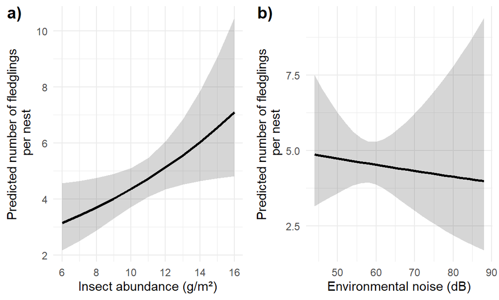

```r
# Plot predictions
  prediction_plot
```

A Poisson Generalized Linear Model (R² = 0.299, $\chi^2_{(2,37)}$ = 13.807, p = 0.0010041) performed significantly better than a null model comprising an intercept only.

Insect abundance had a significant positive effect on the number of fledglings per nest (β = 0.081, SE = 0.036, z = 2.273, p = 0.023), indicating that higher food availability is associated with increased reproductive success.

In contrast, environmental noise showed a small negative effect, but this was not statistically significant (β = -0.005, SE = 0.015, z = -0.313, p = 0.754), suggesting no strong evidence for an effect of noise on fledgling number in this dataset.

These patterns are reflected in Figure 4, where predicted fledgling numbers increase with insect abundance but show only a weak decline with increasing environmental noise.